# Will My Gas Money Get Me Further If My Car Has A Manual Transmission ?

JRB

October 10, 2016

## Exploratory Data Analysis

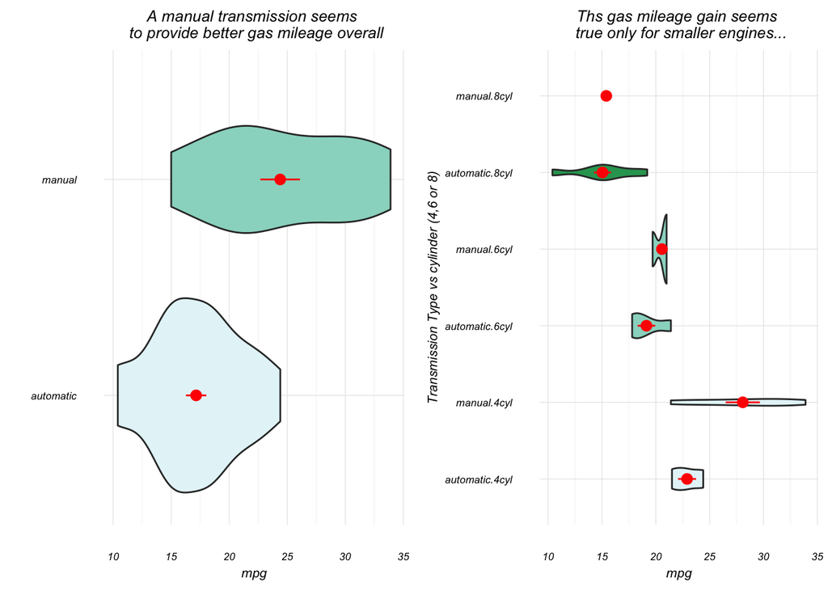

This simple data exploration helps us generate two assumptions we need to verify…  
1. *Assumption #1:* Manual transmissions provides better mpg  
2. *Assumption #2:* Better mpg is only significant for smaller engines

## Model selection

We will explore there multivariate regression models:

- Model 1: `mpg ~ factor(am)` mpg against transmission type|
- Model 2: `mpg ~ factor(am) + factor(am):factor(cyl)` mpg against transmission type as a regressor and an interaction term between number of cylinders and transmission
- Model 3: `mpg ~ factor(am) + factor(cyl) + factor(am):factor(cyl)` mpg against transmission type an dnumber of cylinders as regressors and an intercation factor bewteen transmission and number of cylinders.

Analysis of Variance Table

| Res.Df | RSS | Df | Sum of Sq | F | Pr(>F) |
| --- | --- | --- | --- | --- | --- |
| 30 | 720.9 | NA | NA | NA | NA |
| 26 | 239.1 | 4 | 481.8 | 13.1 | 0 |
| 26 | 239.1 | 0 | 0 | NA | NA |

The anova test reveals that model 2 is the most approriate we could pick. Model 3 is not adding any information.

## Is there a mpg gain with manual cars ?

Model 1 is interesting to use to prove the assumption that on average (with out distinction on cylinder count) manual transmission have better fuel economy.

Fitting linear model: mpg ~ factor(am)

|  | Estimate | Std. Error | t value | Pr(>\|t\|) |
| --- | --- | --- | --- | --- |
| **factor(am)automatic** | -7.24 | 1.76 | -4.11 | 0 |
| **(Intercept)** | 24.39 | 1.36 | 17.94 | 0 |

We re-leveled the factors of `mtcars` to use manual as a reference point. The coeficient is interpreted by the difference of the mean between manual cars mpg and automatic cars mpg. A negative coefficient indicates a better mpg for manual cars. The significance level tells us that the coefficient is different that 0. This is confirmed by a t.test reproduce in appendix 1. Using this model we can quantify the average gain in mpg for manual cars, it is simply obtain by taking the absolute value of the model coeficient, in our case `7.245` mpg gain. We can also note that the intercept value is the mean mpg for manual cars.  
So we can state that on average manual cars are more gas efficient than automatic cars.

## Is this mpg gain true for all cylinders ?

[output not shown]

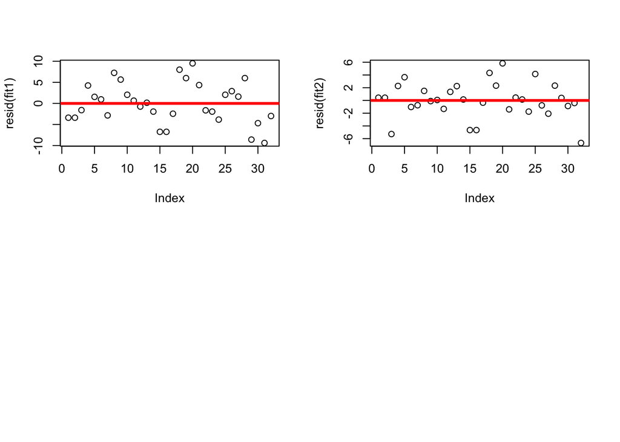

```r
      par(mfrow=c(2,2))
        plot(resid(fit1));abline(h=0,col="red",lwd=3);plot(resid(fit2));abline(h=0,col="red",lwd=3)
```

# Appendix 1

## t.test of Automatic vs manual mpg

Welch Two Sample t-test: `mycars$mpg` by `mycars$am` The t-test is of the mpg variable against the am variable as a factor with two levels and using manual as the reference level. so $H_a: \mu_{manual} > \mu_{automatic}$. We conclude that manual cars have a better mpg than automatic ones on average and without consideration for any other possible interactions.

| Test statistic | df | P value | Alternative hypothesis |
| --- | --- | --- | --- |
| 3.77 | 18.33 | 0 * * * | greater |